# Final 216 project_Junxiao

# Introduction

Skin cancer is a major public health concern, with over 5 million cases diagnosed in the United States each year (American Cancer Society, 2021). Early detection is critical for successful treatment and prevention of skin cancer. However, current methods of screening and diagnosis are limited and often rely on visual inspection, which can be subjective and prone to errors (Codella et al., 2019). Machine learning has the potential to improve the accuracy and efficiency of skin cancer screening by using non-invasive methods and leveraging large amounts of data.

In this study, our research question is: Can machine learning models accurately classify individuals at risk of developing skin cancer based on their behavioral and demographic characteristics? We will use the Behavioral Risk Factor Surveillance System (BRFSS) of 2014 as our training data and the BRFSS of 2015 as our testing data. We will focus on five key predictors: sex, race, age, education level, and history of depression. We will compare the performance of five different machine learning models: logistic regression, linear discriminant analysis, elastic net regression, support vector machines, and random forests.

By answering this research question, we hope to contribute to the development of more effective and efficient screening methods for skin cancer, which could ultimately lead to better health outcomes and reduced healthcare costs.

# Methods

In this study, we used various machine learning algorithms to develop a predictive model for classifying individuals at risk of developing skin cancer based on their behavioral and demographic characteristics. Variable subset selection using forward selection was used to identify the most important predictors of skin cancer risk from a large set of potential predictors. We used logistic regression, linear discriminant analysis, elastic net regression, cross-validation, support vector machine, and Random forests to predict the risk of developing skin cancer.

```r
# Prepare the dataset.
# Wirte the data of 2014 and 2015
#write.csv(dat2015brfss, file = "C:/Study 2022-2023/2023 winter/216 Machine Learning in R for the Biomedical Sciences/216 project/final_data_2015.csv")
#write.csv(dat2014brfss, file = "C:/Study 2022-2023/2023 winter/216 Machine Learning in R for the Biomedical Sciences/216 project/final_data_2014.csv")

# Reload the data to train data and test data
dat_train <- read.csv( "C:/Study 2022-2023/2023 winter/216 Machine Learning in R for the Biomedical Sciences/216 project/final_data_2014.csv")
dat_test <- read.csv( "C:/Study 2022-2023/2023 winter/216 Machine Learning in R for the Biomedical Sciences/216 project/final_data_2015.csv")

# Count the number of NA values in each column
na_counts_train <- colSums(is.na(dat_train))
na_counts_test <- colSums(is.na(dat_test))

# Identify the columns of variables
columns_to_keep <- c("GENHLTH", "MEDCOST", "ADDEPEV2", "SEX", "MARITAL", "QLACTLM2", "EXERANY2", "X_RACE", "X_BMI5CAT", "X_EDUCAG", "X_INCOMG", "X_RFSMOK3", "DRNKANY5", "CHCSCNCR", "X_AGE_G", "PHYSHLTH")

dat2_train <- subset(dat_train, select = columns_to_keep)
dat2_test <- subset(dat_test, select = columns_to_keep)

library(tidyr)
library(dplyr)
dat2_train <- dat2_train %>% filter(!is.na(GENHLTH) & !is.na(MEDCOST) & !is.na(ADDEPEV2) & !is.na(SEX) & !is.na(MARITAL) & !is.na(QLACTLM2) & !is.na(EXERANY2) & !is.na(X_RACE) & !is.na(X_BMI5CAT) & !is.na(X_EDUCAG) & !is.na(X_INCOMG) & !is.na(X_RFSMOK3) & !is.na(DRNKANY5) & !is.na(CHCSCNCR) & !is.na(X_AGE_G) & !is.na(PHYSHLTH))
dat2_test <- dat2_test %>% filter(!is.na(GENHLTH) & !is.na(MEDCOST) & !is.na(ADDEPEV2) & !is.na(SEX) & !is.na(MARITAL) & !is.na(QLACTLM2) & !is.na(EXERANY2) & !is.na(X_RACE) & !is.na(X_BMI5CAT) & !is.na(X_EDUCAG) & !is.na(X_INCOMG) & !is.na(X_RFSMOK3) & !is.na(DRNKANY5) & !is.na(CHCSCNCR) & !is.na(X_AGE_G) & !is.na(PHYSHLTH))
```

## Variable subset selection using forward selection

According to the result, there are 16 missing values in “ADDEPEV2”, 509 missing values in “X_RACE”, 8 missing values in “X_EDUCAG”, and 13 missing values in “CHCSCNCR” in training data. And there are 27 missing values in “ADDEPEV2”, 534 missing values in “X_RACE”, 19 missing values in “X_EDUCAG”, and 16 missing values in “CHCSCNCR”. “SEX” and “X_AGE_G” have no missing values in training data and testing data. Exclude the data with missing values.

```r
# install.packages("leaps")
library(leaps)
regfit <-  regsubsets(CHCSCNCR ~., data=dat2_train, nvmax = 8, nbest = 1, method="forward", really.big=True)
coef(regfit, 8)
```

```
##  (Intercept)     ADDEPEV2          SEX     QLACTLM2       X_RACE    X_BMI5CAT
##  1.911399106  0.030557554  0.039365198  0.015859717  0.013308587  0.008106300
##     X_EDUCAG    X_RFSMOK3      X_AGE_G
## -0.007139129  0.028825121 -0.046191359
```

```r
# Cleaning data
columns_to_keep2 <- c("ADDEPEV2", "SEX", "X_RACE", "X_EDUCAG", "CHCSCNCR", "X_AGE_G")

dat3_train <- subset(dat_train, select = columns_to_keep2)
dat3_test <- subset(dat_test, select = columns_to_keep2)

# change X_RACE = 0 to NA (can't find the defination of X_RACE = 0 in codesbook)
dat3_train$X_RACE[dat3_train$X_RACE == 0] <- NA
dat3_test$X_RACE[dat3_test$X_RACE == 0] <- NA
# change ADDEPEV2 = 2 to 0
dat3_train$ADDEPEV2[dat3_train$ADDEPEV2 == 2] <- 0
dat3_test$ADDEPEV2[dat3_test$ADDEPEV2 == 2] <- 0

# Count the number of NA values in each column
na_counts3_train <- colSums(is.na(dat3_train))
na_counts3_test <- colSums(is.na(dat3_test))
# Print the results
print(na_counts3_train)
```

```
## ADDEPEV2      SEX   X_RACE X_EDUCAG CHCSCNCR  X_AGE_G
##       16        0      509        8       13        0
```

```r
print(na_counts3_test)
```

```
## ADDEPEV2      SEX   X_RACE X_EDUCAG CHCSCNCR  X_AGE_G
##       27        0      534       19       16        0
```

```r
library(tidyr)
library(dplyr)
dat3_train <- dat3_train %>% filter(!is.na(X_RACE) & !is.na(X_EDUCAG) & !is.na(ADDEPEV2) & !is.na(SEX) & !is.na(CHCSCNCR) & !is.na(X_AGE_G))
dat3_test <- dat3_test %>% filter(!is.na(X_RACE) & !is.na(X_EDUCAG) & !is.na(ADDEPEV2) & !is.na(SEX) & !is.na(CHCSCNCR) & !is.na(X_AGE_G))

dat3_train$CHCSCNCR <- ifelse(dat3_train$CHCSCNCR > 1, 0, dat3_train$CHCSCNCR)
table(dat3_train$CHCSCNCR)
```

```
##
##    0    1
## 3979  486
```

```r
dat3_test$CHCSCNCR <- ifelse(dat3_test$CHCSCNCR > 1, 0, dat3_test$CHCSCNCR)
table(dat3_test$CHCSCNCR)
```

```
##
##    0    1
## 3985  432
```

```r
# We use Sex(1 - Male; 2 - Female), race (X _RACE, 1: White only, non-Hispanic; 2: Black only, non-; 3: American Indian or Alaskan Native only, Non-Hispanic ;  4: Asian only, non-Hispanic;  5: Native Hawaiian or other Pacific Islander only, Non-Hispanic; 6: Other race only, non-Hispanic), Age (X_AGE_G: 1 - Age 18 to 24; 2 - Age 25 to 34; 3 - Age 35 to 44; 4 - Age 45 to 54; 5 - Age 55 to 64; 6 - Age 65 or older), education level (X_EDUCAG: 1 - Did not graduate High School; 2 - Graduated High School; 3 - Attended College or Technical School; 4 - Graduated from College or Technical School), and have a depressive disorder, including depression, major depression, dysthymia, or minor depression (ADDEPEV2: 1 – Yes, 0 – No) for prediction. Outcome is skin cancer (CHCSCNCR: 1 – Yes, 0 – No).
```

# Results

## Demographic

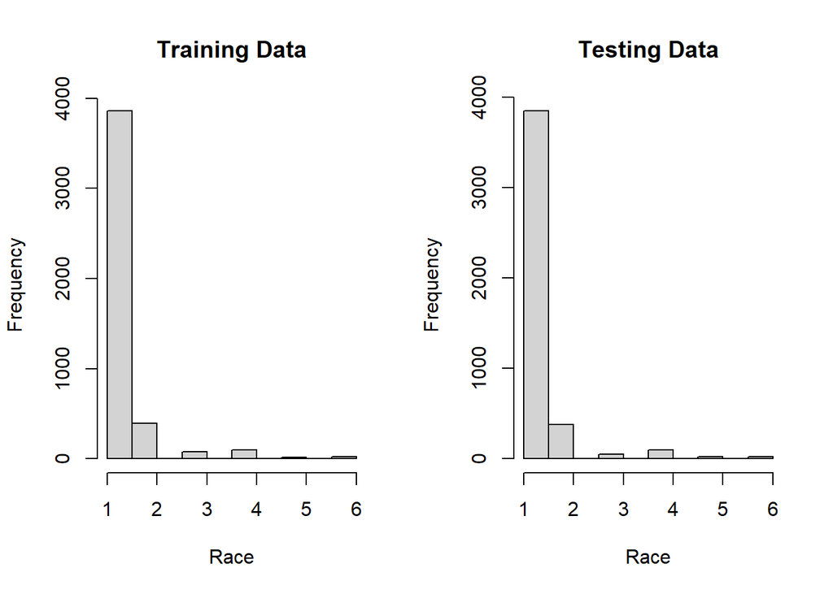

```r
# Set up the plotting area to have two columns
par(mfrow=c(1,2))

# Plot the histogram for the training data
hist(dat3_train$X_RACE, main="Training Data", xlab="Race")

# Plot the histogram for the testing data
hist(dat3_test$X_RACE, main="Testing Data", xlab="Race")
```

```r
# Create a table for training data
train_table <- table(dat3_train$X_AGE_G, dat3_train$CHCSCNCR)
colnames(train_table) <- c("No", "Yes")
rownames(train_table) <- c("18-24", "25-34", "35-44", "45-54", "55-64", "65+")
train_table <- cbind(train_table, rowSums(train_table))
colnames(train_table)[3] <- "Total"
train_table
```

```
##         No Yes Total
## 18-24  198   1   199
## 25-34  360   2   362
## 35-44  450   7   457
## 45-54  679  39   718
## 55-64  928  98  1026
## 65+   1364 339  1703
```

```r
# Create a table for testing data
test_table <- table(dat3_test$X_AGE_G, dat3_test$CHCSCNCR)
colnames(test_table) <- c("No", "Yes")
rownames(test_table) <- c("18-24", "25-34", "35-44", "45-54", "55-64", "65+")
test_table <- cbind(test_table, rowSums(test_table))
colnames(test_table)[3] <- "Total"
test_table
```

```
##         No Yes Total
## 18-24  180   0   180
## 25-34  374   4   378
## 35-44  422  13   435
## 45-54  695  26   721
## 55-64  959  93  1052
## 65+   1355 296  1651
```

```r
# Create a table for sex in training data
train_sex_table <- table(dat3_train$SEX)
names(train_sex_table) <- c("Female", "Male")
train_sex_table
```

[output not shown]

```r
# Create a table for sex in testing data
test_sex_table <- table(dat3_test$SEX)
names(test_sex_table) <- c("Female", "Male")
test_sex_table
```

[output not shown]